# Goodness of fit statistics

## 1 Setup

**R**

Install `vcd` and `fitdistrplus` packages.

```r
install.packages(c("vcd", "fitdistrplus"))
```

```r
library(vcd)
library(fitdistrplus)
```

**Python**

Load modules

```python
import scipy.stats as st
from scipy.optimize import minimize
import numpy as np
import pandas as pd
```

**Julia**

Install modules

```julia
using Pkg
Pkg.add(["HypothesisTests", "StatsBase"])
```

Load packages

```julia
using Distributions
using Random
using HypothesisTests
using Optim
using StatsBase
using DelimitedFiles
using DataFrames
```

## 2 Exercise for the lecture

**R**

```r
set.seed(1)
n <- 10000
x <- rnbinom(n, mu = 3, size = 2)
## or
x <- rnbinom(n, prob = 2/(2+3), size = 2)
x_length <- length(table(x))
x_dof <- 1+2
x_fitted <- fitdistr(x = x, densfun = "negative binomial") ## using MASS::fitdistr
x_fitted
```

```
      size          mu
  1.93175062   3.03419777
 (0.04833430) (0.02793143)
```

The same using `fitdistrplus` package

```r
fitdist(x, "nbinom")
```

```
Fitting of the distribution ' nbinom ' by maximum likelihood
Parameters:
     estimate Std. Error
size 1.931667 0.04833039
mu   3.034178 0.02793152
```

`fitdistrplus` package have PDF and CDF plots for assessing the fit.

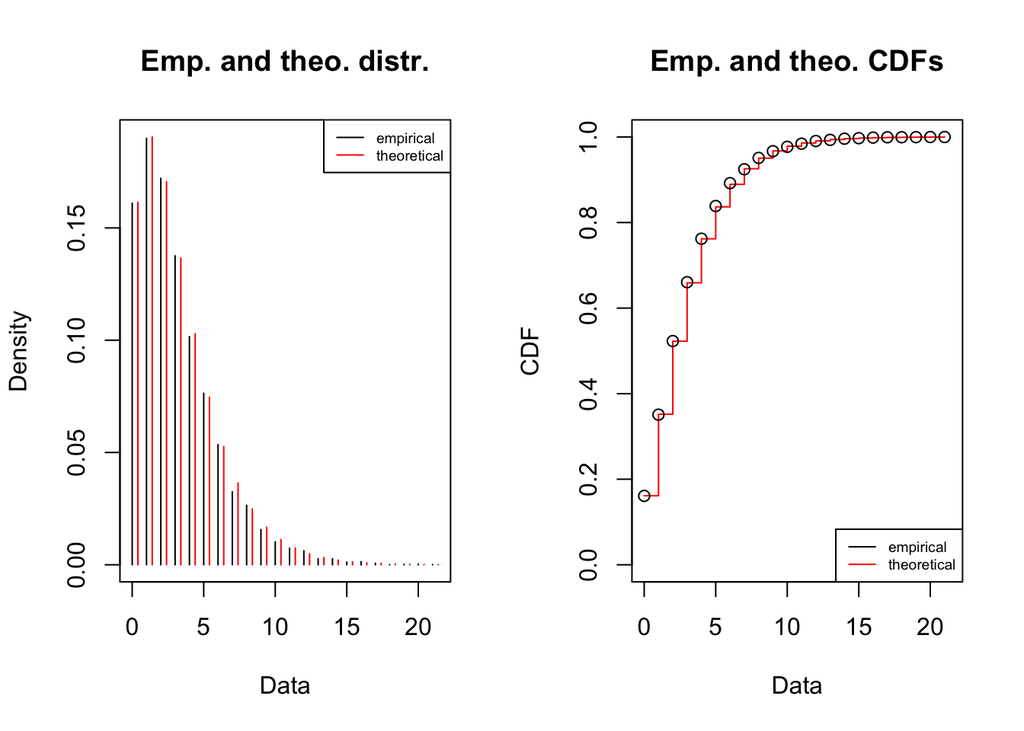

```r
fitdist(x, "nbinom") |> plot()
```

save data for other languages

```r
cat(x, sep = "\n", file = "nb_sim.txt")
```

Small note regarding the `vcd` package. It gives correct answers but in a slightly different way.

1. `goodfit` function returns a list with `fitted` (expected) frequencies under a given distribution using `pdf` of this distribution
2. `summary(goodfit object)` returns a $\chi^2$ and $G^2$ tests using `cdf` of a given distribution. 3. Pearson residuals are calculated as

$$\widehat{\text{resid}}_{k,\text{Pearson}} = \frac{n_k - \hat{n}_k}{\sqrt{\hat{n}_k}}$$

Thus, if we use `object$fitted` created by `goodfit` to calculate $\chi^2$ and $G^2$ statistics by hand we will get slightly different statistics values than the one returned by `summary.goodfit()` function. Thus, both are accepted results.

In this material, we use the first approach in Python and Julia.

```r
gof_nb <- goodfit(x, "nbinomial")
gof_po <- goodfit(x, "poisson")
gof_nb
```

[output not shown]

```r
summary(gof_nb)
```

```
     Goodness-of-fit test for nbinomial distribution

                      X^2 df  P(> X^2)
Likelihood Ratio 24.16794 19 0.1897891
```

```r
summary(gof_po)
```

```
     Goodness-of-fit test for poisson distribution

                      X^2 df P(> X^2)
Likelihood Ratio 5580.672 20        0
```

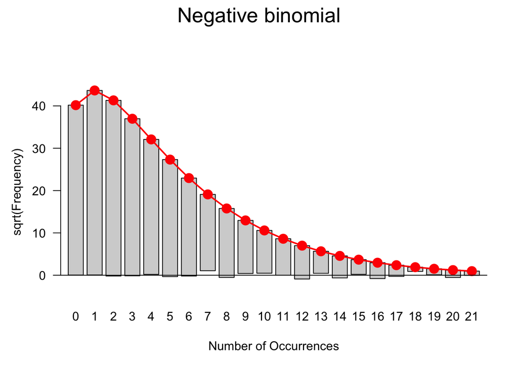

```r
rootogram(gof_nb, main = "Negative binomial")
```

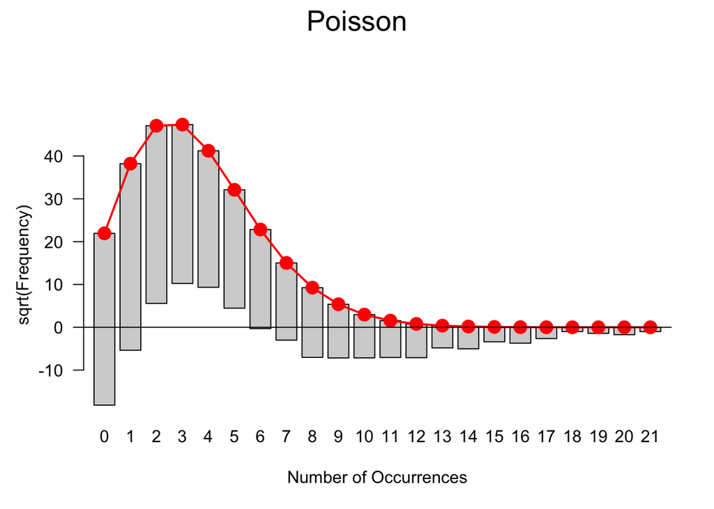

```r
rootogram(gof_po, main = "Poisson")
```

**Python**

Python uses a different specification of negative binomial than we specified in R so we need to rewrite it as follows:

$$p = \frac{\text{size}}{\text{size} + \mu}.$$

```python
np.random.seed(1)
N = 1000
x = st.nbinom(n = 2, p = 2/(2+3)).rvs(N)
np.mean(x)
```

```
3.09
```

However, these pseudo-random numbers are not the same as in R. So, to make our example comparable with R, we read data generated from R that was saved to text file.

```python
x = np.loadtxt("nb_sim.txt", dtype = np.int64)
np.mean(x)
```

```
3.0338
```

Optimization using pmf function

```python
def pdf_nbinom(par, x):
  pdfnbinom = st.nbinom(par[0],par[1]).logpmf(x)
  return -np.sum(pdfnbinom)

res = minimize(fun=pdf_nbinom, x0=[2, 0.5], args = (x), method = "Nelder-Mead")
res
```

```
       message: Optimization terminated successfully.
       success: True
        status: 0
           fun: 22196.043169998586
             x: [ 1.931e+00  3.890e-01]
           nit: 37
          nfev: 70
 final_simplex: (array([[ 1.931e+00,  3.890e-01],
                       [ 1.932e+00,  3.890e-01],
                       [ 1.931e+00,  3.890e-01]]), array([ 2.220e+04,  2.220e+04,  2.220e+04]))
```

```python
res.x
```

```
array([1.93147265, 0.38900007])
```

**Goodness of fit – step by step**

$G^2$ and $\chi^2$ GoF can be calculated using `scipy.stats.power_divergence` function

```python
x_uniq_vals, x_uniq_counts = np.unique(x, return_counts=True)
## we simply use pdf(NB(2.01357331, 0.40157875), x)
est_pdf = st.nbinom(res.x[0],res.x[1]).pmf(x_uniq_vals)
est_pdf = est_pdf/np.sum(est_pdf)
np.round(est_pdf*100,)
```

```
array([16., 19., 17., 14., 10.,  7.,  5.,  4.,  2.,  2.,  1.,  1.,  0.,
        0.,  0.,  0.,  0.,  0.,  0.,  0.,  0.,  0.])
```

$G^2$ test

```python
st.power_divergence(x_uniq_counts,
                    sum(x_uniq_counts)*est_pdf,
                    lambda_ = 0, ddof = 2)
```

```
Power_divergenceResult(statistic=20.868402450945787, pvalue=0.34411771304356253)
```

$\chi^2$ test

```python
st.power_divergence(x_uniq_counts,
                    sum(x_uniq_counts)*est_pdf,
                    lambda_ = 1, ddof = 2)
```

```
Power_divergenceResult(statistic=21.167317905477404, pvalue=0.32762978979776164)
```

**Rootograms** are not available in python. There are some scripts that recreate this plot using `matplotlib`, see https://stackoverflow.com/questions/38252879/how-to-plot-a-hanging-rootogram-in-python

**Julia**

```julia
Random.seed!(123);
n = 1000;
x = rand(NegativeBinomial(2, 2/(2+3)), n);
mean(x)
```

```
3.003
```

However, these pseudo-random numbers are not the same as in R. So, to make our example comparable with R, we read data generated from R that was saved to text file.

```julia
x = readdlm("nb_sim.txt", Int);
x = vec(x);
mean(x)
```

```
3.0338
```

```julia
function llnb(par, data)
  ll = logpdf.(NegativeBinomial(par[1], par[2]), data)
  return -sum(ll)
end
```

```
llnb (generic function with 1 method)
```

```julia
res = optimize(par -> llnb(par, x), [2, 0.5])
```

```
 * Status: success

 * Candidate solution
    Final objective value:     2.219604e+04

 * Found with
    Algorithm:     Nelder-Mead

 * Convergence measures
    √(Σ(yᵢ-ȳ)²)/n ≤ 1.0e-08

 * Work counters
    Seconds run:   0  (vs limit Inf)
    Iterations:    44
    f(x) calls:    89
```

```julia
res.minimizer
```

```
2-element Vector{Float64}:
 1.931482451554722
 0.38899766227761556
```

Goodness of fit statistics

```julia
x_uniq_dict = sort(countmap(x));
x_uniq_vals = Int.(keys(x_uniq_dict));
x_uniq_counts = Int.(values(x_uniq_dict));
x_params = res.minimizer;
est_pdf = pdf.(NegativeBinomial(x_params[1], x_params[2]), x_uniq_vals);
est_pdf = est_pdf ./ sum(est_pdf);
```

$G^2$ test

```julia
PowerDivergenceTest(x_uniq_counts, lambda = 0.0, theta0 = est_pdf)
```

```julia
Multinomial Likelihood Ratio Test
---------------------------------
Population details:
    parameter of interest:   Multinomial Probabilities
    value under h_0:         [0.162756, 0.192213, 0.171812, 0.137132, 0.102889, 0.074243, 0.0521512, 0.03592, 0.0243722, 0.0163424, 0.0108539, 0.00715202, 0.0046816, 0.00304727, 0.00197386, 0.00127317, 0.000818163, 0.000334669, 3.4335e-5]
    point estimate:          [0.16, 0.195, 0.17, 0.137, 0.114, 0.068, 0.052, 0.033, 0.019, 0.02, 0.006, 0.014, 0.005, 0.002, 0.001, 0.001, 0.001, 0.001, 0.001]
    95% confidence interval: [(0.131, 0.1891), (0.166, 0.2241), (0.141, 0.1991), (0.108, 0.1661), (0.085, 0.1431), (0.039, 0.09709), (0.023, 0.08109), (0.004, 0.06209), (0.0, 0.04809), (0.0, 0.04909), (0.0, 0.03509), (0.0, 0.04309), (0.0, 0.03409), (0.0, 0.03109), (0.0, 0.03009), (0.0, 0.03009), (0.0, 0.03009), (0.0, 0.03009), (0.0, 0.03009)]

Test summary:
    outcome with 95% confidence: fail to reject h_0
    one-sided p-value:           0.4174

Details:
    Sample size:        1000
    statistic:          18.591632916708782
    degrees of freedom: 18
    residuals:          [-0.216012, 0.200997, -0.138238, -0.0112519, 1.09536, -0.724547, -0.0209416, -0.487213, -1.08818, 0.904765, -1.47332, 2.56064, 0.147156, -0.599932, -0.693168, -0.242094, 0.201031, 1.15008, 5.21144]
    std. residuals:     [-0.236076, 0.223635, -0.151902, -0.0121131, 1.15647, -0.75304, -0.02151, -0.496206, -1.10169, 0.91225, -1.48139, 2.56985, 0.147502, -0.600848, -0.693853, -0.242248, 0.201113, 1.15028, 5.21153]
```

Correct p-value for the correct number of dof.

```julia
1-cdf(Chisq(19), 18.591632916708782)
```

```
0.48329964025737626
```

$\chi^2$ test

```julia
PowerDivergenceTest(x_uniq_counts, lambda = 1.0, theta0 = est_pdf)
```

```julia
Pearson's Chi-square Test
-------------------------
Population details:
    parameter of interest:   Multinomial Probabilities
    value under h_0:         [0.162756, 0.192213, 0.171812, 0.137132, 0.102889, 0.074243, 0.0521512, 0.03592, 0.0243722, 0.0163424, 0.0108539, 0.00715202, 0.0046816, 0.00304727, 0.00197386, 0.00127317, 0.000818163, 0.000334669, 3.4335e-5]
    point estimate:          [0.16, 0.195, 0.17, 0.137, 0.114, 0.068, 0.052, 0.033, 0.019, 0.02, 0.006, 0.014, 0.005, 0.002, 0.001, 0.001, 0.001, 0.001, 0.001]
    95% confidence interval: [(0.131, 0.1891), (0.166, 0.2241), (0.141, 0.1991), (0.108, 0.1661), (0.085, 0.1431), (0.039, 0.09709), (0.023, 0.08109), (0.004, 0.06209), (0.0, 0.04809), (0.0, 0.04909), (0.0, 0.03509), (0.0, 0.04309), (0.0, 0.03409), (0.0, 0.03109), (0.0, 0.03009), (0.0, 0.03009), (0.0, 0.03009), (0.0, 0.03009), (0.0, 0.03009)]

Test summary:
    outcome with 95% confidence: reject h_0
    one-sided p-value:           0.0010

Details:
    Sample size:        1000
    statistic:          42.242072813765624
    degrees of freedom: 18
    residuals:          [-0.216012, 0.200997, -0.138238, -0.0112519, 1.09536, -0.724547, -0.0209416, -0.487213, -1.08818, 0.904765, -1.47332, 2.56064, 0.147156, -0.599932, -0.693168, -0.242094, 0.201031, 1.15008, 5.21144]
    std. residuals:     [-0.236076, 0.223635, -0.151902, -0.0121131, 1.15647, -0.75304, -0.02151, -0.496206, -1.10169, 0.91225, -1.48139, 2.56985, 0.147502, -0.600848, -0.693853, -0.242248, 0.201113, 1.15028, 5.21153]
```

```julia
1-cdf(Chisq(19), 42.242072813765624)
```

```
0.0016437407784998248
```

## 3 Example from the lecture

**R**

Vector with data from the lecture

```r
X <- rep(0:4, c(100,50,15,5,1))
X_tab <- table(X)
X_tab
```

```
X
  0   1   2   3   4
100  50  15   5   1
```

Check if Poisson distribution fits the data

```r
X_po <- goodfit(X, "poisson")
X_po
```

[output not shown]

Step by step:

1. estimate $\lambda$.

```r
lambda_hat <- mean(X)
lambda_hat
```

```
[1] 0.5789474
```

2. get expected values

```r
n_hat <- length(X)*dpois(0:4, lambda_hat)
n_hat
```

```
[1] 95.8434555 55.4883163 16.0624074  3.0997628  0.4486499
```

3. get pearson residual

```r
r_hat <- (as.vector(X_tab)-n_hat)/sqrt(n_hat)
r_hat
```

```
[1]  0.4245719 -0.7367809 -0.2650854  1.0793035  0.8231400
```

4. Save the result into a table

```r
X_dt <- data.frame(X = 0:4, n = as.vector(X_tab), n_hat = n_hat, r_hat = r_hat)
X_dt
```

```
  X   n      n_hat      r_hat
1 0 100 95.8434555  0.4245719
2 1  50 55.4883163 -0.7367809
3 2  15 16.0624074 -0.2650854
4 3   5  3.0997628  1.0793035
5 4   1  0.4486499  0.8231400
```

Check if negative binomial distribution fits the data better.

```r
X_nb <- goodfit(X, "nbinom")
X_nb
```

```
Observed and fitted values for nbinomial distribution
with parameters estimated by `ML'

 count observed     fitted pearson residual
     0      100 99.8591355     0.0140963797
     1       50 49.9942956     0.0008067754
     2       15 15.8955037    -0.2246106044
     3        5  4.0858714     0.4522357893
     4        1  0.9258398    -0.1530363159
```

Let’s now look at $G^2$ test. Results indicate that Poisson and negative binomial distribution fit the data equally well.

```r
summary(X_po)
```

```
     Goodness-of-fit test for poisson distribution

                      X^2 df  P(> X^2)
Likelihood Ratio 2.407058  3 0.4923221
```

```r
summary(X_nb)
```

```
     Goodness-of-fit test for nbinomial distribution

                       X^2 df  P(> X^2)
Likelihood Ratio 0.7268915  2 0.6952764
```

Now, let’s see what AIC, BIC and LR test will say.

```r
X_fit_ll_po <- fitdistr(X, "poisson")
X_fit_ll_nb <- fitdistr(X, "negative binomial")
```

The lower the better – Poisson seems to be a better distribution

```r
AIC(X_fit_ll_po, X_fit_ll_nb)
```

```
            df      AIC
X_fit_ll_po  1 353.2838
X_fit_ll_nb  2 353.6036
```

The lower the better – Poisson seems to be a better distribution. Note that in this case the difference is higher due to larger number of parameters for NB, so BIC suggest distribution with lower number of parameters.

```r
BIC(X_fit_ll_po, X_fit_ll_nb)
```

```
            df      BIC
X_fit_ll_po  1 356.4254
X_fit_ll_nb  2 359.8869
```

Now, let’s see what LR test will tell. For this example it seems that two distributions equally well fit the data.

```r
LR_test <- 2*X_fit_ll_nb$loglik - 2*X_fit_ll_po$loglik
LR_test_p <- pchisq(LR_test, 1, lower.tail = F)
data.frame(LR=LR_test, df = 1, p_val = LR_test_p)
```

```
        LR df     p_val
1 1.680167  1 0.1949023
```

**Conclusion**: based only on the data we cannot indicate which distribution fit the data better.

**Python**

Code in Python that reproduce R results.

```python
## generate data
X = np.concatenate([np.repeat(i, n) for i, n in enumerate([100, 50, 15, 5, 1])])
## frequency table
X_tab = pd.Series(X).value_counts()
## estimated lambda
lambda_hat = np.mean(X)
## fitted counts
n_hat = len(X) * st.poisson.pmf(np.arange(0, 5), lambda_hat)
## pearson residual
r_hat = (X_tab.values - n_hat) / np.sqrt(n_hat)
## store results in data.frame
X_dt = pd.DataFrame({'X': np.arange(0, 5), 'n': X_tab.values, 'n_hat': n_hat, 'r_hat': r_hat})
X_dt
```

```
   X    n      n_hat     r_hat
0  0  100  95.843455  0.424572
1  1   50  55.488316 -0.736781
2  2   15  16.062407 -0.265085
3  3    5   3.099763  1.079303
4  4    1   0.448650  0.823140
```

```python
## loglik for n
def pdf_nbinom(par, x):
  pdfnbinom = st.nbinom(par[0],par[1]).logpmf(x)
  return -np.sum(pdfnbinom)

res_nb = minimize(fun=pdf_nbinom, x0=[2, 0.5], args = (X), method = "Nelder-Mead")
ll_po = sum(st.poisson(np.mean(X)).logpmf(X))
ll_nb = -res_nb.fun
LR_test =  2*ll_nb - 2*ll_po
[LR_test, 1, 1 - st.chi2.cdf(LR_test, 1)]
```

```
[1.6801666923731773, 1, 0.19490230449303525]
```

```python
AIC_po = 2*1 - 2*ll_po
AIC_nb = 2*2 - 2*ll_nb
[AIC_nb, AIC_po]
```

```
[353.6036049382796, 353.2837716306528]
```

```python
BIC_po = np.log(len(X))*1 - 2*ll_po
BIC_nb = np.log(len(X))*2 - 2*ll_nb
[BIC_nb, BIC_po]
```

```
[359.88693205128493, 356.4254351871554]
```

**Julia**

```julia
X = vcat([fill(i-1,n) for (i, n) in enumerate([100,50,15,5,1])]...);
X_tab = sort(countmap(X));
lambda_hat = mean(X);
n_hat = length(X) * pdf.(Poisson(lambda_hat), 0:4);
r_hat = (values(X_tab) .- n_hat) ./ sqrt.(n_hat);
X_dt = DataFrame(X = 0:4, n = values(X_tab).*1, n_hat = n_hat, r_hat = r_hat)
```

```
5×4 DataFrame
 Row │ X      n      n_hat     r_hat
     │ Int64  Int64  Float64   Float64
─────┼───────────────────────────────────
   1 │     0    100  95.8435    0.424572
   2 │     1     50  55.4883   -0.736781
   3 │     2     15  16.0624   -0.265085
   4 │     3      5   3.09976   1.0793
   5 │     4      1   0.44865   0.82314
```